# stream drawing words with video elements

stream drawing words with video elements

in this stream we explore some recent visualization work and apply it to words/letters. we wind up with interactive letters composed of videos.

In [ ]

markdown

actions

```
# stream drawing words with video elements

in this stream we explore some recent visualization work and apply it to words/letters. we wind up with interactive letters composed of videos.
```

3

# stream drawing words with video elements

in this stream we explore some recent visualization work and apply it to words/letters. we wind up with interactive letters composed of videos.

In [ 1 ]

code

actions

```
%%
&nbsp;

<iframe width="560" height="315" src="https://www.youtube.com/embed/1yMSyusdjMU?si=GUiYfUTfV_nB7eVj" title="YouTube video player" frameborder="0" allow="accelerometer; autoplay; clipboard-write; encrypted-media; gyroscope; picture-in-picture; web-share" referrerpolicy="strict-origin-when-cross-origin" allowfullscreen></iframe>
```

4

[video not shown]

In [ 2 ]

code

actions

```
    import matplotlib.pyplot
    ax = matplotlib.pyplot.gca()
    fig = matplotlib.pyplot.gcf()
    ax.axis("off")
    ax.text(0, 0, "fuck", size=100)
    fig.savefig(file := "word.png")
```

6

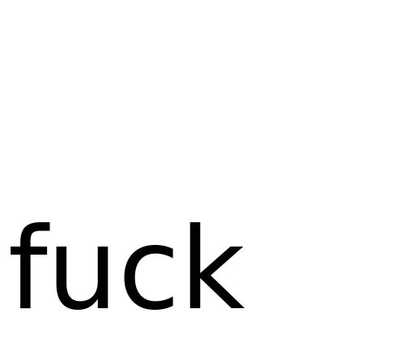

In [ ]

markdown

actions

```
## modify the image with `skimage`
```

1

In [ 3 ]

code

actions

```
    import skimage.io, skimage.morphology, skimage.color

    df = pandas.DataFrame()
    im = 1-skimage.color.rgb2gray(skimage.io.imread(file)[:,:,:3]).round()
    im >= .5
    im = skimage.morphology.skeletonize(im)
    df = DataFrame(im)
    series = df.stack()[df.stack() > .5]

    df = DataFrame(map(list, series.index.values), columns=list("yx"))
    df.T
```

11

|  | 0 | 1 | 2 | 3 | 4 | 5 | 6 | 7 | 8 | 9 | ... | 663 | 664 | 665 | 666 | 667 | 668 | 669 | 670 | 671 | 672 |
| --- | --- | --- | --- | --- | --- | --- | --- | --- | --- | --- | --- | --- | --- | --- | --- | --- | --- | --- | --- | --- | --- |
| y | 325 | 325 | 326 | 326 | 326 | 326 | 326 | 326 | 326 | 326 | ... | 423 | 424 | 424 | 424 | 424 | 425 | 425 | 425 | 426 | 426 |
| x | 126 | 127 | 114 | 115 | 116 | 117 | 118 | 119 | 120 | 121 | ... | 362 | 363 | 364 | 365 | 366 | 367 | 368 | 369 | 370 | 371 |

2 rows × 673 columns

In [ 4 ]

code

actions

````
%%
## css styling for the letters

{{css.data}}

    css=\
```html
<style>
#letters {
    --width: 600px;
    --height: 400px;
    height: var(--height);
    width: var(--width);
    tbody {
        position: relative;
        tr {
            display: block;
            width: 2rem;
            height: 2rem;
            --dx: calc((var(--x) - var(--x_min))/(var(--x_max) - var(--x_min)));
            --dy: calc((var(--y) - var(--y_min))/(var(--y_max) - var(--y_min)));
            position: absolute;
            border-radius: 100% 100%;
            transform:
                translateX(calc(var(--dx) * var(--width)))
                translateY(calc(var(--dy) * var(--height)));
        }
    }
}
</style>
```
````

31

## css styling for the letters

```
css=\
```

```html
<style>
#letters {
    --width: 600px;
    --height: 400px;
    height: var(--height);
    width: var(--width);
    tbody {
        position: relative;
        tr {
            display: block;
            width: 2rem;
            height: 2rem;
            --dx: calc((var(--x) - var(--x_min))/(var(--x_max) - var(--x_min)));
            --dy: calc((var(--y) - var(--y_min))/(var(--y_max) - var(--y_min)));
            position: absolute;
            border-radius: 100% 100%;
            transform:
                translateX(calc(var(--dx) * var(--width)))
                translateY(calc(var(--dy) * var(--height)));
        }
    }
}
</style>
```

In [ 8 ]

code

actions

````
%%
## camera selection

select a camera or direction to activate the video streaming in the points.

{{html.data}}

    html =\
```html
<form name=one class=webcam>
    <label for=camera>cameras</label>
    <select name=camera></select>
    <select name=direction>
        <option value=user>forward</option>
        <option value=environment>back</option>
    </select>
    <br/>
    <video autoplay></video>
</form>

<script>
Array.from(document.getElementsByClassName("webcam")).forEach(
    (form) => {
        let [video] = form.getElementsByTagName("video");
        let camera = form.querySelector("[name=camera]");
        let direction = form.querySelector("[name=direction]");
        if (!navigator.mediaDevices?.enumerateDevices) {
          console.log("enumerateDevices() not supported.");
        } else {
          navigator.mediaDevices
            .enumerateDevices({video: true, audio: false})
            .then((devices) => {
              devices.forEach((device) => {updateVideoSources(device, camera)});
            })
            .catch((err) => {console.error(`${err.name}: ${err.message}`);});
        }
        function change(){
            console.log("changing source");
            navigator.mediaDevices.getUserMedia({
                video: {
                    facingMode: form.elements.direction.value,
                    deviceId: {
                        exact: form.elements.camera.value
                    }
                }, audio: false
            })
          .then((stream) => {
              document.querySelectorAll(".cams").forEach(
                  video => video.srcObject = stream
              )
            })
          .catch(console.log);
        }
        change();
        camera.addEventListener("change", change);
        direction.addEventListener("change", change);
    }
)
function updateVideoSources(device, camera){
    if (device.kind == "videoinput") {
      let option = document.createElement('option');
      if (!camera.querySelector(`[value="${device.deviceId}"]`)){
          option.setAttribute("value", device.deviceId);
          option.insertAdjacentHTML( 'beforeend', device.label || "unknown" );
          camera.appendChild(option);
      }
  };
}
updateVideoSources()
</script>
```
````

71

## camera selection

select a camera or direction to activate the video streaming in the points.

cameras

[video not shown]

```
html =\
```

```html
<form name=one class=webcam>
    <label for=camera>cameras</label>
    <select name=camera></select>
    <select name=direction>
        <option value=user>forward</option>
        <option value=environment>back</option>
    </select>
    <br/>
    <video autoplay></video>
</form>

<script>
Array.from(document.getElementsByClassName("webcam")).forEach(
    (form) => {
        let [video] = form.getElementsByTagName("video");
        let camera = form.querySelector("[name=camera]");
        let direction = form.querySelector("[name=direction]");
        if (!navigator.mediaDevices?.enumerateDevices) {
          console.log("enumerateDevices() not supported.");
        } else {
          navigator.mediaDevices
            .enumerateDevices({video: true, audio: false})
            .then((devices) => {
              devices.forEach((device) => {updateVideoSources(device, camera)});
            })
            .catch((err) => {console.error(`${err.name}: ${err.message}`);});
        }
        function change(){
            console.log("changing source");
            navigator.mediaDevices.getUserMedia({
                video: {
                    facingMode: form.elements.direction.value,
                    deviceId: {
                        exact: form.elements.camera.value
                    }
                }, audio: false
            })
          .then((stream) => {
              document.querySelectorAll(".cams").forEach(
                  video => video.srcObject = stream
              )
            })
          .catch(console.log);
        }
        change();
        camera.addEventListener("change", change);
        direction.addEventListener("change", change);
    }
)
function updateVideoSources(device, camera){
    if (device.kind == "videoinput") {
      let option = document.createElement('option');
      if (!camera.querySelector(`[value="${device.deviceId}"]`)){
          option.setAttribute("value", device.deviceId);
          option.insertAdjacentHTML( 'beforeend', device.label || "unknown" );
          camera.appendChild(option);
      }
  };
}
updateVideoSources()
</script>
```

In [ 9 ]

code

actions

[output not shown]

19

## a fuck in plot

```
def style_attrs(row, post=""):
    out = io.StringIO()
    for k, v in row.items():
        out.write("--"), out.write(k), out.write(post), out.write(": "), out.write(str(v)), out.write("; ")
    return out.getvalue()
```

In [ ]

markdown

actions

```
### matplotlib view
```

1

### matplotlib view

In [ 7 ]

code

actions

```
    df.plot.scatter(*"xy")
```

1

```
<Axes: xlabel='x', ylabel='y'>
```

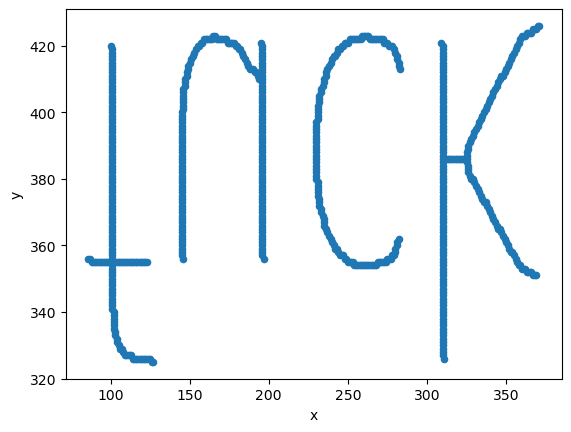

In [ None ]

code

actions